# BUDT 758X Project Proposal: Career Analysis

#### Group 10 (Group One ): Jiading Chen, Changnan Jing, Yuanhao Zhang, Shlok Jethwa

## Introduction

As current students of the Information Systems program, and with diverse backgrounds, the main problem that a student faces is to decide in which direction should he/she forward his/her career. This is due to the reason that many of us have done an undergraduate in business, the software side, the electrical side, etc. Therefore this project will help them to anticipate what kind of work pays the most amount of money (P.S Money is very important :-P). This project will show the different kinds of salaries by college attended, program majored and even the region of living. In a nutshell, a student can decide their career plan based on our project.

Questions of Interest

What are the benefits of studying in the Ivy League as compared to other universities?

Which region has the best starting salary in the U.S at graduation and mid-career?

What are the salary figures of students from different universities ten years down the line?

What are the school rankings based on salaries now and even ten years after graduation?

What are the majors that offer the most salary increase in the coming years after graduation?

What are the significant factors that affect mid-career salary and how significant are they?

# 1. Tyding Data

#### Read csv file we need and install basic packages

Data source: https://www.kaggle.com/wsj/college-salaries#salaries-by-college-type.csv

Package Installation. Major packages we used in this project is pandas and matplotlib.

```python
import pandas as pd
import numpy as np
import matplotlib.pyplot as plt
import re
import sklearn
import seaborn as sns
import statsmodels.api as sm
import plotly.graph_objects as go
from geopy.geocoders import Nominatim
from bs4 import BeautifulSoup
import requests
geolocator = Nominatim(user_agent="specify_your_app_name_here")
import socket
s = socket.socket()
s.settimeout(1000)
```

We first read data in pandas dataframe and then cast string data from object to string and numeric data to float for further analysis and modification.

```python
#User header to access the website
header = {
  "User-Agent": "Mozilla/5.0 (X11; Linux x86_64) AppleWebKit/537.36 (KHTML, like Gecko) Chrome/50.0.2661.75 Safari/537.36",
  "X-Requested-With": "XMLHttpRequest"
}
poke_url = 'https://github.com/chshaw/SAT-ACT-Scores/blob/master/data/sat_2017.csv'
r = requests.get(poke_url, headers=header)
#Convert html into a dataframe
dfs = pd.read_html(r.text)
df = dfs[0].sort_values(by='State', ascending=True)
df = df.drop('Unnamed: 0',axis=1)
#Read state to get abrreviation for state
#state = pd.read_csv('states.csv')
#df['State'] = state['Abbreviation']
df.head()
```

|  | State | Participation | Evidence-Based Reading and Writing | Math | Total |
| --- | --- | --- | --- | --- | --- |
| 0 | Alabama | 5% | 593 | 572 | 1165 |
| 1 | Alaska | 38% | 547 | 533 | 1080 |
| 2 | Arizona | 30% | 563 | 553 | 1116 |
| 3 | Arkansas | 3% | 614 | 594 | 1208 |
| 4 | California | 53% | 531 | 524 | 1055 |

```python
college_type = pd.read_csv('/Users/zhangyuanhao/Desktop/758X/college-salaries/salaries-by-college-type.csv')
college_type['School Type'] = college_type['School Type'].astype(str)
dummies = pd.get_dummies(college_type['School Type'])
college_type = pd.concat([college_type, dummies], axis = 1)
college_type = college_type.dropna()
college_type.head()
```

|  | School Name | School Type | Starting Median Salary | Mid-Career Median Salary | Mid-Career 10th Percentile Salary | Mid-Career 25th Percentile Salary | Mid-Career 75th Percentile Salary | Mid-Career 90th Percentile Salary | Engineering | Ivy League | Liberal Arts | Party | State |
| --- | --- | --- | --- | --- | --- | --- | --- | --- | --- | --- | --- | --- | --- |
| 0 | Massachusetts Institute of Technology (MIT) | Engineering | $72,200.00 | $126,000.00 | $76,800.00 | $99,200.00 | $168,000.00 | $220,000.00 | 1 | 0 | 0 | 0 | 0 |
| 3 | Polytechnic University of New York, Brooklyn | Engineering | $62,400.00 | $114,000.00 | $66,800.00 | $94,300.00 | $143,000.00 | $190,000.00 | 1 | 0 | 0 | 0 | 0 |
| 5 | Worcester Polytechnic Institute (WPI) | Engineering | $61,000.00 | $114,000.00 | $80,000.00 | $91,200.00 | $137,000.00 | $180,000.00 | 1 | 0 | 0 | 0 | 0 |
| 6 | Carnegie Mellon University (CMU) | Engineering | $61,800.00 | $111,000.00 | $63,300.00 | $80,100.00 | $150,000.00 | $209,000.00 | 1 | 0 | 0 | 0 | 0 |
| 7 | Rensselaer Polytechnic Institute (RPI) | Engineering | $61,100.00 | $110,000.00 | $71,600.00 | $85,500.00 | $140,000.00 | $182,000.00 | 1 | 0 | 0 | 0 | 0 |

#### Clean data

After reading in data, we need to do a further cleaning to make our data more readable and manipulatable.

```python
cols = ['Starting Median Salary',
       'Mid-Career Median Salary', 'Mid-Career 10th Percentile Salary',
       'Mid-Career 25th Percentile Salary',
       'Mid-Career 75th Percentile Salary',
       'Mid-Career 90th Percentile Salary']
# Filter out unnecessary symbols for analysis
for col in cols:
    college_type[col] = college_type[col].str.replace('$','')
    college_type[col] = college_type[col].str.replace(',','')

#Cast string to float
for j in range(2,8):
    for i in range(len(college_type)):
        college_type.iloc[i,j] = float(college_type.iloc[i,j])

#Clean and categorize data
college_type_engineering = college_type[college_type['Engineering'] == 1].iloc[:,0:-5]
college_type_IL = college_type[college_type['Ivy League'] == 1].iloc[:,0:-5]
college_type_LA = college_type[college_type['Liberal Arts'] == 1].iloc[:,0:-5]
college_type_state = college_type[college_type['State'] == 1].iloc[:,0:-5]
college_type_party = college_type[college_type['Party'] == 1].iloc[:,0:-5]
```

# 2. Exploratary Data Analysis and Data Visualization

### 2.1 Analysis about types and regions of school

First, we are going to start our analysis with different types of universities. We choose to use mean value of data to represent the average level of categories.

```python
college_type_engineering_mean = college_type_engineering.mean()
college_type_IL_mean = college_type_IL.mean()
college_type_LA_mean = college_type_LA.mean()
college_type_state_mean = college_type_state.mean()
college_type_party_mean = college_type_party.mean()
college_type_salary_mean = [college_type_engineering_mean, college_type_IL_mean, college_type_LA_mean, college_type_state_mean, college_type_party_mean]
college_type_salary = pd.DataFrame(college_type_salary_mean).T
college_type_salary.columns = list(college_type['School Type'].unique())
college_type_salary
```

|  | Engineering | Party | Liberal Arts | Ivy League | State |
| --- | --- | --- | --- | --- | --- |
| Starting Median Salary | 57440.000000 | 60475.0 | 46171.428571 | 44126.285714 | 45878.947368 |
| Mid-Career Median Salary | 101373.333333 | 120125.0 | 89635.714286 | 78567.428571 | 84742.105263 |
| Mid-Career 10th Percentile Salary | 61793.333333 | 57900.0 | 47478.571429 | 41886.285714 | 44052.631579 |
| Mid-Career 25th Percentile Salary | 79913.333333 | 82787.5 | 63235.714286 | 56689.714286 | 60315.789474 |
| Mid-Career 75th Percentile Salary | 130433.333333 | 184125.0 | 127828.571429 | 106970.857143 | 117842.105263 |
| Mid-Career 90th Percentile Salary | 173333.333333 | 269625.0 | 191142.857143 | 147571.428571 | 166947.368421 |

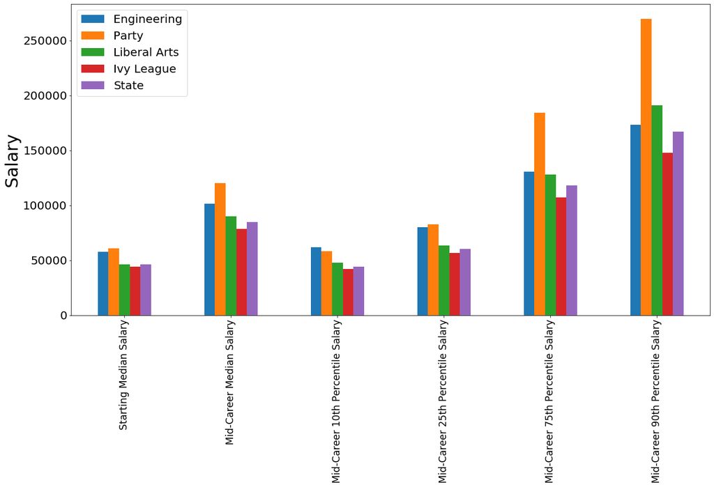

```python
#draw a barplot about the salary of different school type
college_type_salary.plot(kind = 'bar',figsize = (20,10))
plt.ylabel('Salary', fontsize = 30)
plt.xticks(rotation = 'vertical',fontsize = 17)
plt.yticks(fontsize = 20)
plt.legend(fontsize = 20)
plt.show()
```

From the bar polt, we are suprised to see that party schools have the highest salary in most periods of time. What's more, the party schools have a more rapid increasing speed of salary, which is contrary to what we think normally.

We continue to analyze salary distribution according to different regions in the U.S.

```python
#prepare the data for radar plot
c_t = college_type_salary.T
c_t_eng = c_t.loc['Engineering']
c_t_party = c_t.loc['Party']
c_t_LA = c_t.loc['Liberal Arts']
c_t_IL = c_t.loc['Ivy League']
c_t_S = c_t.loc['State']
```

```python
c_t_S
```

```
Starting Median Salary                45878.947368
Mid-Career Median Salary              84742.105263
Mid-Career 10th Percentile Salary     44052.631579
Mid-Career 25th Percentile Salary     60315.789474
Mid-Career 75th Percentile Salary    117842.105263
Mid-Career 90th Percentile Salary    166947.368421
Name: State, dtype: float64
```

```python
pip install pygal
```

```python
#draw a radar plot about the salary of different school types
import pygal
#call radar and set the parameters
radar_chart = pygal.Radar(fill = True, range=(10000,300000))
radar_chart.title = 'Salary By School Type'
#set label for each angle
radar_chart.x_labels = ['Starting','Mid-Career 10th','Mid-Career 25th','Mid-Career','Mid-Career 75th','Mid-Career 90th']

#draw the lines
radar_chart.add('Engineer', c_t_eng)
radar_chart.add('Party', c_t_party)
radar_chart.add('Liberal Arts', c_t_LA)
radar_chart.add('Ivy League', c_t_IL)
radar_chart.add('State', c_t_S)
radar_chart.render_to_file('/Users/zhangyuanhao/Desktop/758X/college-salaries/radar_chart.svg')
```

```python
# dsiplay the radar plot
from IPython.display import SVG, display
def show_svg():
    display(SVG('/Users/zhangyuanhao/Desktop/758X/college-salaries/radar_chart.svg'))
```

```python
show_svg()
```

[interactive chart not shown]

From the radar plot, we can see that  
1.A funny one: The students in party school have the highest salaries in almost every stage and the students in Ivy league have the lowest ones.  
2.The salary difference in party school is largest, and the difference in Ivy League is smallest.  
We think the reason why we get that conclusion is the admission criteria and level of majors in party schools varies greatly, so the salary after they graduate varies greatly, and the high salary level students will raise the mean salary. On the contrary, the Ivy League school has close level students and majors, so their salaries are close and more reasonable.

```python
college_region = pd.read_csv('/Users/zhangyuanhao/Desktop/758X/college-salaries/salaries-by-region.csv')
college_region['Region'] = college_region['Region'].astype(str)
dummies = pd.get_dummies(college_region['Region'])
college_region = pd.concat([college_region, dummies], axis = 1)
#college_type.drop('Party', axis = 1, inplace = True)
college_region = college_region.dropna()
college_region.head()
```

|  | School Name | Region | Starting Median Salary | Mid-Career Median Salary | Mid-Career 10th Percentile Salary | Mid-Career 25th Percentile Salary | Mid-Career 75th Percentile Salary | Mid-Career 90th Percentile Salary | California | Midwestern | Northeastern | Southern | Western |
| --- | --- | --- | --- | --- | --- | --- | --- | --- | --- | --- | --- | --- | --- |
| 0 | Stanford University | California | $70,400.00 | $129,000.00 | $68,400.00 | $93,100.00 | $184,000.00 | $257,000.00 | 1 | 0 | 0 | 0 | 0 |
| 3 | University of California, Berkeley | California | $59,900.00 | $112,000.00 | $59,500.00 | $81,000.00 | $149,000.00 | $201,000.00 | 1 | 0 | 0 | 0 | 0 |
| 5 | Cal Poly San Luis Obispo | California | $57,200.00 | $101,000.00 | $55,000.00 | $74,700.00 | $133,000.00 | $178,000.00 | 1 | 0 | 0 | 0 | 0 |
| 6 | University of California at Los Angeles (UCLA) | California | $52,600.00 | $101,000.00 | $51,300.00 | $72,500.00 | $139,000.00 | $193,000.00 | 1 | 0 | 0 | 0 | 0 |
| 7 | University of California, San Diego (UCSD) | California | $51,100.00 | $101,000.00 | $51,700.00 | $75,400.00 | $131,000.00 | $177,000.00 | 1 | 0 | 0 | 0 | 0 |

```python
for col in cols:
    college_region[col] = college_region[col].str.replace('$','')
    college_region[col] = college_region[col].str.replace(',','')
for j in range(2,8):
    for i in range(len(college_region)):
        college_region.iloc[i,j] = float(college_region.iloc[i,j])

college_type_engineering_mean = college_type_engineering.mean()
college_type_IL_mean = college_type_IL.mean()
college_type_LA_mean = college_type_LA.mean()
college_type_state_mean = college_type_state.mean()
college_type_party_mean = college_type_party.mean()
college_type_salary_mean = [college_type_engineering_mean, college_type_IL_mean, college_type_LA_mean, college_type_state_mean, college_type_party_mean]
college_type_salary = pd.DataFrame(college_type_salary_mean).T
college_type_salary.columns = list(college_type['School Type'].unique())
college_type_salary
```

|  | Engineering | Party | Liberal Arts | Ivy League | State |
| --- | --- | --- | --- | --- | --- |
| Starting Median Salary | 57440.000000 | 60475.0 | 46171.428571 | 44126.285714 | 45878.947368 |
| Mid-Career Median Salary | 101373.333333 | 120125.0 | 89635.714286 | 78567.428571 | 84742.105263 |
| Mid-Career 10th Percentile Salary | 61793.333333 | 57900.0 | 47478.571429 | 41886.285714 | 44052.631579 |
| Mid-Career 25th Percentile Salary | 79913.333333 | 82787.5 | 63235.714286 | 56689.714286 | 60315.789474 |
| Mid-Career 75th Percentile Salary | 130433.333333 | 184125.0 | 127828.571429 | 106970.857143 | 117842.105263 |
| Mid-Career 90th Percentile Salary | 173333.333333 | 269625.0 | 191142.857143 | 147571.428571 | 166947.368421 |

```python
college_region_CA = college_region[college_region['California'] == 1].iloc[:,0:-5]
college_region_W = college_region[college_region['Western'] == 1].iloc[:,0:-5]
college_region_MW = college_region[college_region['Midwestern'] == 1].iloc[:,0:-5]
college_region_S = college_region[college_region['Southern'] == 1].iloc[:,0:-5]
college_region_NE = college_region[college_region['Northeastern'] == 1].iloc[:,0:-5]
college_region_CA_mean = college_region_CA.mean()
college_region_W_mean = college_region_W.mean()
college_region_MW_mean = college_region_MW.mean()
college_region_S_mean = college_region_S.mean()
college_region_NE_mean = college_region_NE.mean()
college_region_salary_mean = [college_region_CA_mean, college_region_W_mean,college_region_MW_mean,college_region_S_mean,college_region_NE_mean]
college_region_salary = pd.DataFrame(college_region_salary_mean).T
college_region_salary.columns = list(college_region['Region'].unique())
college_region_salary
```

|  | California | Western | Midwestern | Southern | Northeastern |
| --- | --- | --- | --- | --- | --- |
| Starting Median Salary | 50072.727273 | 44932.352941 | 44460.9375 | 44946.478873 | 48679.268293 |
| Mid-Career Median Salary | 91718.181818 | 79541.176471 | 78178.1250 | 80018.309859 | 90929.268293 |
| Mid-Career 10th Percentile Salary | 47777.272727 | 42985.294118 | 43076.5625 | 43074.647887 | 49101.219512 |
| Mid-Career 25th Percentile Salary | 66686.363636 | 57741.176471 | 57348.4375 | 58008.450704 | 65715.853659 |
| Mid-Career 75th Percentile Salary | 123618.181818 | 106891.176471 | 106864.0625 | 110022.535211 | 127606.097561 |
| Mid-Career 90th Percentile Salary | 167909.090909 | 143823.529412 | 147689.0625 | 152769.014085 | 181926.829268 |

### Tidying data for the following analysis

Because latitide and longitude of schools are needed in the following analysis, we decide to extract them at first. As a result, we can improve the analysis corresponsding to regions further.

```python
# Merge data together
college_type2 = college_type.drop(['Engineering', 'Ivy League', 'Liberal Arts', 'Party', 'State'], axis = 1)
college_region2 = college_region.drop(['California', 'Midwestern','Northeastern', 'Southern', 'Western'], axis = 1)
college_merge = pd.merge(left = college_type2, right = college_region2, left_on = 'School Name', right_on = 'School Name')
college_merge = college_merge.dropna()
college_merge2 = college_merge.iloc[:, 0:9]

#There are some location can not be searched by geopy for some reason.
#The following modification are tested in google map
#Manually changed some addresses to other format
college_merge2['Name'] = college_merge2['School Name'].str.replace(r"\(.*\)","")
college_merge2['Name'] = college_merge2['Name'].str.replace("State University of New York ","SUNY")
college_merge2['Name'] = college_merge2['Name'].str.replace("University of Alaska, Anchorage","University of Alaska Anchorage")
college_merge2['Name'] = college_merge2['Name'].str.replace("University of Nevada, Las Vegas","4505 S Maryland Pkwy, Las Vegas, NV 89154")
college_merge2['Name'] = college_merge2['Name'].str.replace("University of Texas at El Paso","500 W University Ave, El Paso, TX 79968")
college_merge2['Name'] = college_merge2['Name'].str.replace("California State University, Dominguez Hills","California State University Dominguez Hills")
college_merge2['Name'] = college_merge2['Name'].str.replace("California State University, Sacramento","6000 J Street, Sacramento, CA 95819")
college_merge2['Name'] = college_merge2['Name'].str.replace("SUNY at Farmingdale","Farmingdale State College")
college_merge2['Name'] = college_merge2['Name'].str.replace("State University of New York ","SUNY")
college_merge2['Name'] = college_merge2['Name'].str.replace("Bowling Green State University","Bowling Green, OH 43403")
college_merge2['Name'] = college_merge2['Name'].str.replace("Georgia Institute of Technology","North Ave NW, Atlanta, GA 30332")
college_merge2['Name'] = college_merge2['Name'].str.replace("Polytechnic University of New York, Brooklyn","Brooklyn, NY 11201")
college_merge2['Name'] = college_merge2['Name'].str.replace("University of Maryland, College Park","University of Maryland-College Park")
college_merge2['Name'] = college_merge2['Name'].str.replace("SUNY at Potsdam","State University of New York at Potsdam")
college_merge2['Name'] = college_merge2['Name'].str.replace("SUNY at Oneonta","108 Ravine Pkwy, Oneonta, NY 13820")
college_merge2['Name'] = college_merge2['Name'].str.replace("SUNY at Geneseo","State University of New York at Geneseo")
college_merge2['Name'] = college_merge2['Name'].str.replace("California State University, Fullerton","800 N State College Blvd, Fullerton, CA 92831")
college_merge2['Name'] = college_merge2['Name'].str.replace("Texas A&M University","400 Bizzell St, College Station, TX 77843")
college_merge2['Name'] = college_merge2['Name'].str.replace("University of Alabama at Huntsville","301 Sparkman Dr NW, Huntsville, AL 35899")
college_merge2['Name'] = college_merge2['Name'].str.replace("University of California at Los Angeles","California, Los Angeles, 90095")

#Temporary lists to store information of latitude and longitude
latitude = []
longitude = []
states =[]
counter = 0
#This is an access to search location
geolocator = Nominatim(user_agent="specify_your_app_name_here")
#Iterate through each rows
for i, x in college_merge2.iterrows():
    #Using try except to extend socket time and prevent timeout error
    try:
        #Using package geopy to get longitude and latitude
        location = geolocator.geocode(x['Name'])
        latitude.append(location.latitude)
        longitude.append(location.longitude)
        state = location.address.split(',')
        states.append(state[-3])

    except:
        location = geolocator.geocode(x['Name'])
        latitude.append(location.latitude)
        longitude.append(location.longitude)
        state = location.address.split(',')
        states.append(state[-3])

college_merge2['Latitude'] = latitude
college_merge2['Longitude'] = longitude
college_merge2['State'] = states
```

```python
#Take the difference of students in different locations into consideration
df.State = df.State.str.replace(' ','') # Standardize format of locations
college_merge2.State = college_merge2.State.str.replace(' ','')
college_merge_final = df.merge(college_merge2, left_on = 'State', right_on = 'State')
college_merge_final = college_merge_final.dropna()
```

```python
# Manually pick the first 8 states among all levels
college_state = college_merge_final.iloc[:,[0,5,7,8,9,10,11,12]]
```

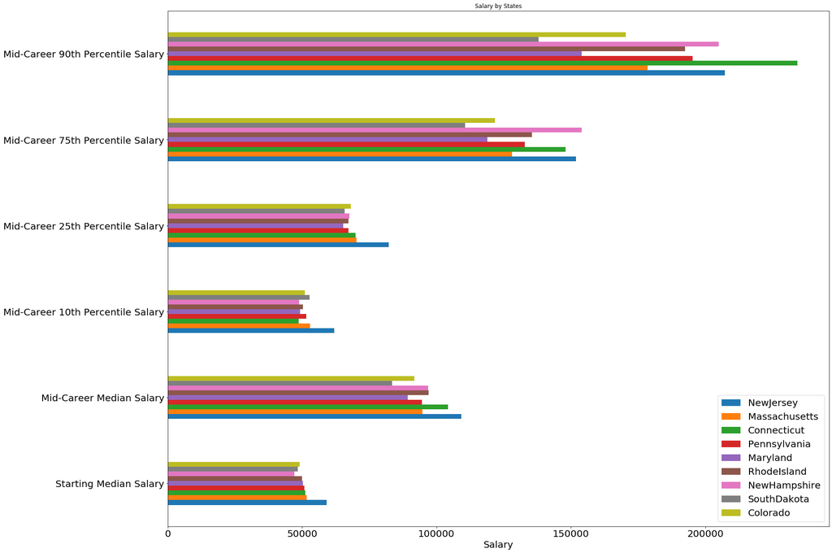

```python
st = ['NewJersey', 'Massachusetts', 'Connecticut','Pennsylvania', 'Maryland','RhodeIsland','NewHampshire','SouthDakota','Colorado']
temp_state = college_state.groupby(by = 'State').mean()
college_state_salary = pd.DataFrame()
for i in st:
    college_state_salary[i] = temp_state.loc[i,:].T
college_state_salary.index = college_state_salary.index.str.replace('_x','')
college_state_salary.plot(kind = 'barh', figsize = (25,20), title = 'Salary by States')
plt.xlabel('Salary', fontsize = 20)
plt.yticks(fontsize = 20)
plt.xticks(fontsize = 20)
plt.legend(fontsize = 20)
```

### 2.2 Further analysis about regions and school types

After seperate analysis about regions and types of universities, we are curious about the comprehensive effect of the two factors, so we are going to combine them to make a deeper analysis.

Create a new variable 'Increasing rate' to reveal the potential career developing ability.

```python
# Give priority to types of schools
college_merge2['Increasing rate'] = college_merge2['Mid-Career Median Salary_x']/college_merge2['Starting Median Salary_x']
college_merge3 = college_merge2.set_index(['School Type', 'State'])
college_merge3 = college_merge3.sort_values(by = 'Increasing rate', ascending = False)
college_merge3.head(10)
```

| School Type | State | School Name | Starting Median Salary_x | Mid-Career Median Salary_x | Mid-Career 10th Percentile Salary_x | Mid-Career 25th Percentile Salary_x | Mid-Career 75th Percentile Salary_x | Mid-Career 90th Percentile Salary_x | Region | Name | Latitude | Longitude | Increasing rate |
| --- | --- | --- | --- | --- | --- | --- | --- | --- | --- | --- | --- | --- | --- |
| Ivy League | NewHampshire | Dartmouth College | 58000 | 134000 | 63100 | 90200 | 234000 | 321000 | Northeastern | Dartmouth College | 43.705244 | -72.290530 | 2.310345 |
| Liberal Arts | Indiana | DePauw University | 41400 | 88300 | 49500 | 57400 | 133000 | 185000 | Midwestern | DePauw University | 39.639768 | -86.861676 | 2.132850 |
| Ivy League | Connecticut | Yale University | 59100 | 126000 | 58000 | 80600 | 198000 | 326000 | Northeastern | Yale University | 41.257131 | -72.989670 | 2.131980 |
| Liberal Arts | Connecticut | Wesleyan University (Middletown, Connecticut) | 46500 | 97900 | 42000 | 62500 | 126000 | 215000 | Northeastern | Wesleyan University | 41.555903 | -72.655988 | 2.105376 |
| State | Colorado | University of Colorado - Boulder (UCB) | 47100 | 97600 | 51600 | 69000 | 128000 | 187000 | Western | University of Colorado - Boulder | 40.006878 | -105.272776 | 2.072187 |
|  | NewYork | State University of New York (SUNY) at Albany | 44500 | 92200 | 47000 | 63100 | 135000 | 209000 | Northeastern | SUNY at Albany | 42.686431 | -73.815715 | 2.071910 |
| Party | NewYork | State University of New York (SUNY) at Albany | 44500 | 92200 | 47000 | 63100 | 135000 | 209000 | Northeastern | SUNY at Albany | 42.686431 | -73.815715 | 2.071910 |
| State | OswegoCounty | State University of New York (SUNY) at Oswego | 38000 | 77800 | 40400 | 53000 | 115000 | 169000 | Northeastern | SUNY at Oswego | 43.452013 | -76.541845 | 2.047368 |
| Liberal Arts | NewYork | Colgate University | 52800 | 108000 | 60000 | 76700 | 167000 | 265000 | Northeastern | Colgate University | 42.821071 | -75.536975 | 2.045455 |
| State | NewYork | State University of New York (SUNY) at Oneonta | 37500 | 76700 | 40000 | 54300 | 97700 | 155000 | Northeastern | 108 Ravine Pkwy, Oneonta, NY 13820 | 42.465682 | -75.061711 | 2.045333 |

```python
# Give priority to school regions
college_merge4 = college_merge2.set_index(['State','School Type', ])
college_merge4 = college_merge4.sort_values(by = 'Increasing rate', ascending = False)
college_merge4.head(10)
```

| State | School Type | School Name | Starting Median Salary_x | Mid-Career Median Salary_x | Mid-Career 10th Percentile Salary_x | Mid-Career 25th Percentile Salary_x | Mid-Career 75th Percentile Salary_x | Mid-Career 90th Percentile Salary_x | Region | Name | Latitude | Longitude | Increasing rate |
| --- | --- | --- | --- | --- | --- | --- | --- | --- | --- | --- | --- | --- | --- |
| NewHampshire | Ivy League | Dartmouth College | 58000 | 134000 | 63100 | 90200 | 234000 | 321000 | Northeastern | Dartmouth College | 43.705244 | -72.290530 | 2.310345 |
| Indiana | Liberal Arts | DePauw University | 41400 | 88300 | 49500 | 57400 | 133000 | 185000 | Midwestern | DePauw University | 39.639768 | -86.861676 | 2.132850 |
| Connecticut | Ivy League | Yale University | 59100 | 126000 | 58000 | 80600 | 198000 | 326000 | Northeastern | Yale University | 41.257131 | -72.989670 | 2.131980 |
|  | Liberal Arts | Wesleyan University (Middletown, Connecticut) | 46500 | 97900 | 42000 | 62500 | 126000 | 215000 | Northeastern | Wesleyan University | 41.555903 | -72.655988 | 2.105376 |
| Colorado | State | University of Colorado - Boulder (UCB) | 47100 | 97600 | 51600 | 69000 | 128000 | 187000 | Western | University of Colorado - Boulder | 40.006878 | -105.272776 | 2.072187 |
| NewYork | State | State University of New York (SUNY) at Albany | 44500 | 92200 | 47000 | 63100 | 135000 | 209000 | Northeastern | SUNY at Albany | 42.686431 | -73.815715 | 2.071910 |
|  | Party | State University of New York (SUNY) at Albany | 44500 | 92200 | 47000 | 63100 | 135000 | 209000 | Northeastern | SUNY at Albany | 42.686431 | -73.815715 | 2.071910 |
| OswegoCounty | State | State University of New York (SUNY) at Oswego | 38000 | 77800 | 40400 | 53000 | 115000 | 169000 | Northeastern | SUNY at Oswego | 43.452013 | -76.541845 | 2.047368 |
| NewYork | Liberal Arts | Colgate University | 52800 | 108000 | 60000 | 76700 | 167000 | 265000 | Northeastern | Colgate University | 42.821071 | -75.536975 | 2.045455 |
|  | State | State University of New York (SUNY) at Oneonta | 37500 | 76700 | 40000 | 54300 | 97700 | 155000 | Northeastern | 108 Ravine Pkwy, Oneonta, NY 13820 | 42.465682 | -75.061711 | 2.045333 |

From the perspective of school type, although party schools have the amazingly highest mid-career salary, Ivy League and Liberal Arts schools have the highest salary increasing rate. From the other perspective, schools in Indiana, New Hampshine and Connecticut own the fasteast increasing rate, who are almost in the northeastern region.

As a result, for students who would like to get a fast growth in their career, they would better to choose Ivy League and Liberal Arts schools in Indiana, New Hampshine and Connecticut. On the other hand, the result also answer our question that Ivy League owns a better location which has a better academic atmosphere. This is the benefit to study there.

### 2.3 Analysis about majors

Since major-choosing is more subjective and isolated from regions and type of schools, we decide to analyze major seperately.

```python
college_major = pd.read_csv('/Users/zhangyuanhao/Desktop/758X/college-salaries/degrees-that-pay-back.csv')

#Since NaN doesn't have function replace, we convert it to 0 for now
for col in cols:
    college_major[col] = college_major[col].str.replace('$','')
    college_major[col] = college_major[col].str.replace(',','')
tem = ['Starting Median Salary','Mid-Career Median Salary','Mid-Career 10th Percentile Salary','Mid-Career 25th Percentile Salary','Mid-Career 75th Percentile Salary','Mid-Career 90th Percentile Salary']
college_major[tem] = college_major[tem].astype(float)
tem =['Starting Median Salary','Mid-Career Median Salary','Mid-Career 75th Percentile Salary']
college_major1 = college_major.sort_values(by=tem, ascending=False)[0:15]
college_major1 = college_major1.reset_index()
```

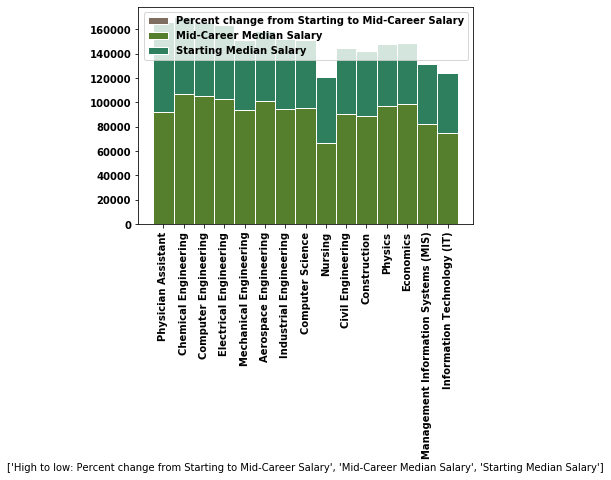

```python
from matplotlib import rc

# y-axis in bold
rc('font', weight='bold')

# Values of each group
bars1 = college_major1['Percent change from Starting to Mid-Career Salary']
bars2 = college_major1['Mid-Career Median Salary']
bars3 = college_major1['Starting Median Salary']

# Heights of bars1 + bars2
bars = np.add(bars1, bars2).tolist()

# The position of the bars on the x-axis
r = [x for x in range(0,15)]

# Names of group and bar width
names = college_major1['Undergraduate Major']
barWidth = 1

# Create brown bars
plt.bar(r, bars1, color='#7f6d5f', edgecolor='white', width=barWidth, label='Percent change from Starting to Mid-Career Salary')
# Create green bars (middle), on top of the firs ones
plt.bar(r, bars2, bottom=bars1, color='#557f2d', edgecolor='white', width=barWidth, label='Mid-Career Median Salary')
# Create green bars (top)
plt.bar(r, bars3, bottom=bars, color='#2d7f5e', edgecolor='white', width=barWidth, tick_label='Starting Median Salary', label='Starting Median Salary')

# Custom X axis
plt.xticks(r, names,rotation='vertical')
plt.xlabel(['High to low: Percent change from Starting to Mid-Career Salary','Mid-Career Median Salary','Starting Median Salary'])
# Show graphic
plt.legend()
```

According to the plot, we can clearly see the top 15 majors with the highest salary in the U.S. In average, students studying the chemical engineering earns the highest salary. Also, we are glad to see Information Systems is one of the top 15 majors with high salary. One of the best things that was observed that Physician assistant might have the largest beginning salary of them all but its Percent change from Starting to Mid-Career Salary is the least.

Plot the result of rankings of different majors

```python
pip install squarify
```

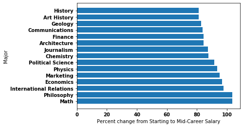

```python
import squarify
college_major2 = college_major.sort_values('Percent change from Starting to Mid-Career Salary', ascending=False)[0:15]

height = college_major2['Undergraduate Major']
bars = college_major2['Percent change from Starting to Mid-Career Salary']
y_pos = np.arange(len(bars))

# Create horizontal bars
plt.barh(y_pos,bars )

# Create names on the y-axis
plt.yticks(y_pos, height)
plt.ylabel("Major")
plt.xlabel('Percent change from Starting to Mid-Career Salary')
# Show graphic
plt.show()
```

From this graph we can see that Math, Philosophy, International Relations, Economics and Marketing are the top 5 undergraduate majors that offer the most salary increase down the line. And Majors like nursing and physician assistant are among the ones which do not see much salary hike in the coming years. Also, we are sad to notice that IS is not in the top list of increasing rate from starting to mid-career.

Hence from the above two graphs you can see that physician assistant has the hugest starting median salary in all branches but when talking about percent change from starting to mid career salary then it is the least. So even if is the most in the beginning one cannot expect much increment after that.

## 2.4 Visualization using mapbox

For guiding graduates more directly, we use mapbox to create a 'salary map' as a guide to show them which regions have a better developing chance.

```python
# Cast Mid-career median salary into string temperarily to make it consistant with school name to be the label in our map
college_merge4['Mid-Career Median Salary_x_1'] = college_merge4['Mid-Career Median Salary_x'].astype(str)
mapbox_access_token = 'pk.eyJ1IjoiamNuMTk5NzI5IiwiYSI6ImNrMm9xNzdiOTE2OXYzY205OG52ZmxhZGQifQ.O2FQnsWlbbYwKPtU0rBTlQ'
college_map_data = go.Scattermapbox(
        lon = college_merge4['Longitude'],
        lat = college_merge4['Latitude'],
        text = college_merge4['School Name'] + '<br>' + 'Mid-Career Median Salary: ' + college_merge4['Mid-Career Median Salary_x_1'],
        hoverinfo='text',
        mode = 'markers',
        marker = dict(
                    color = college_merge4['Mid-Career Median Salary_x'],
                    symbol = 'circle',
                    opacity = .5
                )
)

college_map_layout = go.Layout(
        title = 'Mid-Career Salary of Universities In U.S',
        mapbox=go.layout.Mapbox(
            accesstoken=mapbox_access_token,
            zoom=1
        )
    )

college_map = go.Figure(data=college_map_data, layout=college_map_layout)
college_map.show()
```

[interactive chart not shown]

As the map shows, the points in lighter color represent a higher mid-career salary, and the darker points represent a lower level. The map confirm our conclusion that northeastern of America does have a higher salary level, and help graduates a clear guide when choose the working location to pursue a better development. Now the main question comes regarding how did we get the latitude and longitude of each and every university when we have only the address of all data. For that we imported the library geopy and using that we recieved the output.

# 3. Regression Model and Hypothesis testing

### Null Hypothesis

We are looking at the impacts of:

The salary of mid-career.

#### Null Hypothesis: None of starting salary, region and school type and student's SAT score have noticeable impacts on the mid-career salary.

To test the null hypothesis, we will perform a Multiple Linear Regression on our dataset by using scikit-learn.

We will use our tidied datasets for the features and the target.

Since region and school type are categorical variables, we will create dummy variable for both variabls. To achieve that, we used pd.get_dummies() in this case.

After setting up the data, we will set up X and Y for our use in scikit-learn LinearRegression() function. Then, fit the model.

```python
import seaborn as sns
import statsmodels.api as sm
from scipy import stats
from sklearn import linear_model
from sklearn import model_selection
from statsmodels import api as sm
```

Ordinary Least Squares Regression

```python
tem = ['Region','School Type','Starting Median Salary_x', 'Math','Evidence-Based Reading and Writing']
df_tem = college_merge_final[tem]
X = pd.get_dummies(df_tem,drop_first=True)
X = sm.add_constant(X)
y = college_merge_final['Mid-Career Median Salary_x']
linear = linear_model.LinearRegression()
model = linear.fit(X,y)
linear.score(X,y)
```

```
0.8838294760878127
```

R square is around 0.88, which means that almost every variance is explained by our model.

```python
coef = linear.coef_.tolist()
tem = list(X.columns)
for f, c in zip(tem, coef):
    print("Feature: {}, Coefficient: {}".format(f,c))
```

```
Feature: const, Coefficient: 0.0
Feature: Starting Median Salary_x, Coefficient: 1.9804985807559046
Feature: Math, Coefficient: 4.262733338655871
Feature: Evidence-Based Reading and Writing, Coefficient: 5.257886925459289
Feature: Region_Midwestern, Coefficient: -3350.1657151996683
Feature: Region_Northeastern, Coefficient: 339.16181517789585
Feature: Region_Southern, Coefficient: -1258.592124639769
Feature: Region_Western, Coefficient: -2504.9588923355855
Feature: School Type_Ivy League, Coefficient: 11168.109616685884
Feature: School Type_Liberal Arts, Coefficient: 10377.240815389961
Feature: School Type_Party, Coefficient: 6363.139925276503
Feature: School Type_State, Coefficient: 3947.2466609725775
```

On the other hand, we are surprised to see that only northeastern has a postive coefficient. In average, students graduated from other regions tend to have negative impact on their career.

We want to observe more about this result by p-values, t-values, and std-err. Then, we need Ordinary Least Squares Regression model.

```python
model = sm.OLS(endog=y, exog=X)
results = model.fit()
results.summary()
```

OLS Regression Results

| Dep. Variable: | Mid-Career Median Salary_x | R-squared: | 0.884 |
| --- | --- | --- | --- |
| Model: | OLS | Adj. R-squared: | 0.878 |
| Method: | Least Squares | F-statistic: | 142.5 |
| Date: | Thu, 05 Dec 2019 | Prob (F-statistic): | 7.18e-90 |
| Time: | 12:53:09 | Log-Likelihood: | -2149.6 |
| No. Observations: | 218 | AIC: | 4323. |
| Df Residuals: | 206 | BIC: | 4364. |
| Df Model: | 11 |  |  |
| Covariance Type: | nonrobust |  |  |

|  | coef | std err | t | P>\|t\| | [0.025 | 0.975] |
| --- | --- | --- | --- | --- | --- | --- |
| const | -1.621e+04 | 7884.377 | -2.056 | 0.041 | -3.18e+04 | -666.053 |
| Starting Median Salary_x | 1.9805 | 0.083 | 23.856 | 0.000 | 1.817 | 2.144 |
| Math | 4.2627 | 6.160 | 0.692 | 0.490 | -7.881 | 16.407 |
| Evidence-Based Reading and Writing | 5.2579 | 11.404 | 0.461 | 0.645 | -17.226 | 27.742 |
| Region_Midwestern | -3350.1657 | 1419.796 | -2.360 | 0.019 | -6149.359 | -550.972 |
| Region_Northeastern | 339.1618 | 1373.254 | 0.247 | 0.805 | -2368.272 | 3046.596 |
| Region_Southern | -1258.5921 | 1336.984 | -0.941 | 0.348 | -3894.518 | 1377.333 |
| Region_Western | -2504.9589 | 1440.915 | -1.738 | 0.084 | -5345.790 | 335.872 |
| School Type_Ivy League | 1.117e+04 | 2190.819 | 5.098 | 0.000 | 6848.809 | 1.55e+04 |
| School Type_Liberal Arts | 1.038e+04 | 2104.086 | 4.932 | 0.000 | 6228.937 | 1.45e+04 |
| School Type_Party | 6363.1399 | 2004.017 | 3.175 | 0.002 | 2412.126 | 1.03e+04 |
| School Type_State | 3947.2467 | 1797.347 | 2.196 | 0.029 | 403.694 | 7490.799 |

| Omnibus: | 6.841 | Durbin-Watson: | 1.553 |
| --- | --- | --- | --- |
| Prob(Omnibus): | 0.033 | Jarque-Bera (JB): | 9.023 |
| Skew: | 0.208 | Prob(JB): | 0.0110 |
| Kurtosis: | 3.906 | Cond. No. | 1.17e+06 |

Warnings:  
[1] Standard Errors assume that the covariance matrix of the errors is correctly specified.  
[2] The condition number is large, 1.17e+06. This might indicate that there are  
strong multicollinearity or other numerical problems.

Given the assumption that the covariance matrix of the errors is correctly specified, we may say that the standard Errors are small enough for a good performance.

The R-squared value here is a little bit larger than what we expected. This still gives a good explanation to almost all variances; however, it may also show that our data has a little bit overfitting, which is "the production of an analysis that corresponds too closely or exactly to a particular set of data, and may therefore fail to fit additional data or predict future observations reliably".

Looking at the 'coef' column above, we observe that obviously the School Type_Ivy League has significant impact on the mid-career salary. Also, the p-value of School Type_Ivy League is 0, perfectly below a critical value of 0.05, which confirms more about the findings.

In addition, we are more condifent that it is not true only student graduated from northeastern tend to have a positive impact in their career in average. Based on the observation of the p-values above ('P>|t|' column in the middle chart), we can see that the p-value of Region_Northeastern is way greater than a critical value of 5% (p-value of 0.05).

Also, the p-value of SAT verbal and math are unusually bigger than 5%. Therefore, we conclude that SAT score are not a significant factors for predicting mid-career salary. There is no linear correlation between SAT score and mid-career salary.

# 4. Prediction and Machine Learning

```python
from sklearn.model_selection import train_test_split, KFold, GridSearchCV
from sklearn.preprocessing import StandardScaler
from sklearn.linear_model import LinearRegression
from sklearn.tree import DecisionTreeRegressor, export_graphviz
from sklearn.cluster import KMeans
from sklearn.decomposition import PCA
# Create train/test split
X_train, X_test, y_train, y_test = train_test_split(X, y, test_size=0.3, random_state=12345)
```

```python
# create and fit the linear model
linear = linear_model.LinearRegression()
model = linear.fit(X_train, y_train)

# generate predictions for player Rating to compare with y_test data
predictions = linear.predict(X_test)

# display first 5 results of our predicted mid-career salary.
predictions[0:5]
```

```
array([82031.99775949, 68242.71513675, 81521.28120201, 79498.25914632,
       76051.6727892 ])
```

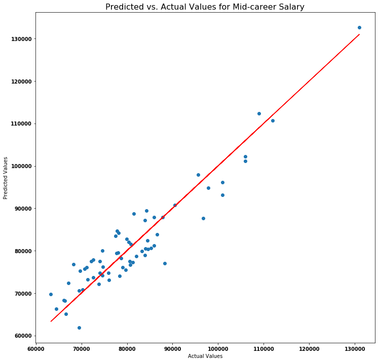

```python
plt.figure(figsize=(12,12))
plt.title("Predicted vs. Actual Values for Mid-career Salary", fontsize=16)
plt.scatter(y_test,predictions)
plt.plot(y_test, y_test, color="Red") # identity line y=x
plt.xlabel("Actual Values")
plt.ylabel("Predicted Values")
plt.show()
```

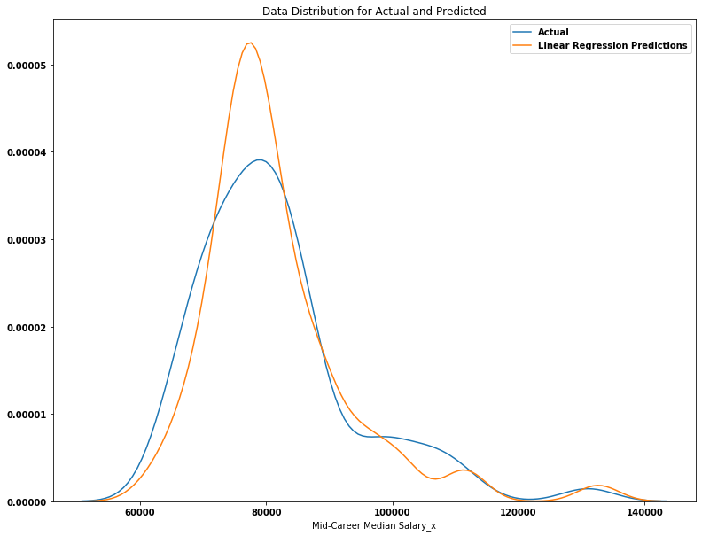

```python
f, ax = plt.subplots(figsize=(13,10))
plt.title('Data Distribution for Actual and Predicted')
sns.distplot(y_test, hist=False, label="Actual", ax=ax)
sns.distplot(predictions, hist=False, label="Linear Regression Predictions", ax=ax)
plt.show()
```

```python
print("Accuracy (scale of 0 to 1): {}".format(model.score(X_test, y_test)))
```

```
Accuracy (scale of 0 to 1): 0.8811988390054758
```

From two plots above, we obviously observe that our model predicted the mid-career salary very well for the testing dataset. Our model also provides a score of the actual accuracy (1 is perfect), and our accuracy is around 0.88, which is a consideratable high accuracy score for the model.

# Appendix

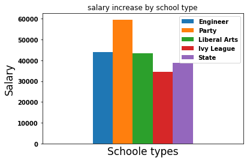

```python
#draw a bar plot of the salary increase by school type
college_type_salary = college_type_salary.reindex(index = ['Starting Median Salary','Mid-Career 10th Percentile Salary','Mid-Career 25th Percentile Salary','Mid-Career Median Salary','Mid-Career 75th Percentile Salary','Mid-Career 90th Percentile Salary',])
xn = ['salary_increase']
college_type_rise = pd.DataFrame(columns = ['Engineer', 'Party', 'Liberal Arts', 'Ivy League','State'])
college_type_rise.loc[1] = [college_type_salary.iloc[3,i] -college_type_salary.iloc[0,i] for i in range(len(college_type_salary.columns))]
college_type_rise.plot(kind = 'bar')
plt.xticks([1],xn)
plt.ylabel('Salary', fontsize = 17)
plt.xlabel('Schoole types', fontsize = 17)
plt.title('salary increase by school type')
```

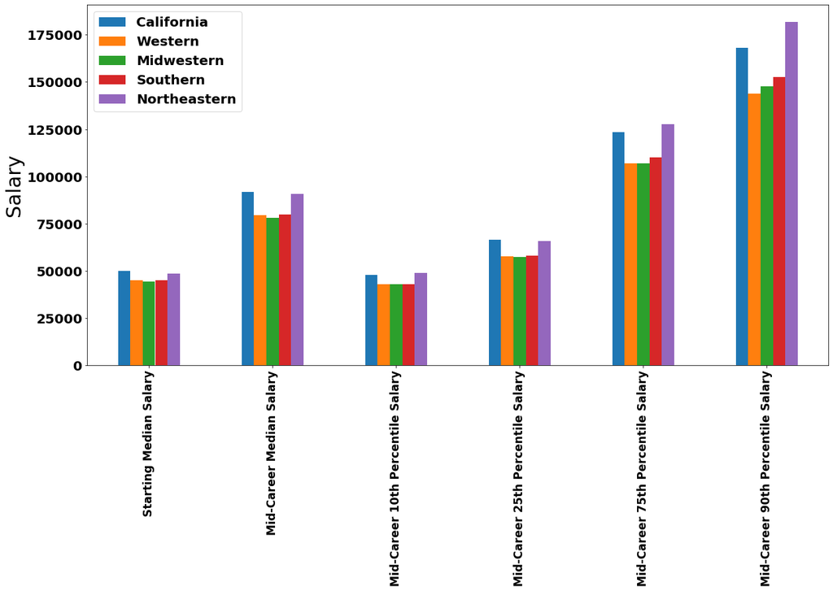

```python
college_region_salary.plot(kind = 'bar', figsize = (20,10))
plt.ylabel('Salary', fontsize = 30)
plt.xticks(rotation = 'vertical', fontsize = 17)
plt.yticks(fontsize = 20)
plt.legend(fontsize = 20)
plt.show()
```